# Scrolling Through Influence: An Instagram Ad Diary

Dewmi Jayatilake

## Introduction

Across two separate logging periods, I recorded a total of 40 Instagram ads that appeared on my personal feed — 20 ads from an earlier project, and another 20 collected recently for this one. I tracked what kind of product was being advertised, the format it showed up in (like Story, Video, Image), whether I recognised the brand, how appealing I thought it was, and whether I interacted with it (clicked, liked, saved, etc.).

This story is based entirely on my own scrolling patterns. It reflects what I see on Instagram, when I see it, and what’s most likely to get me to stop and engage. The patterns turned out to be surprisingly clear — here’s what stood out.

## What Gets Advertised the Most?

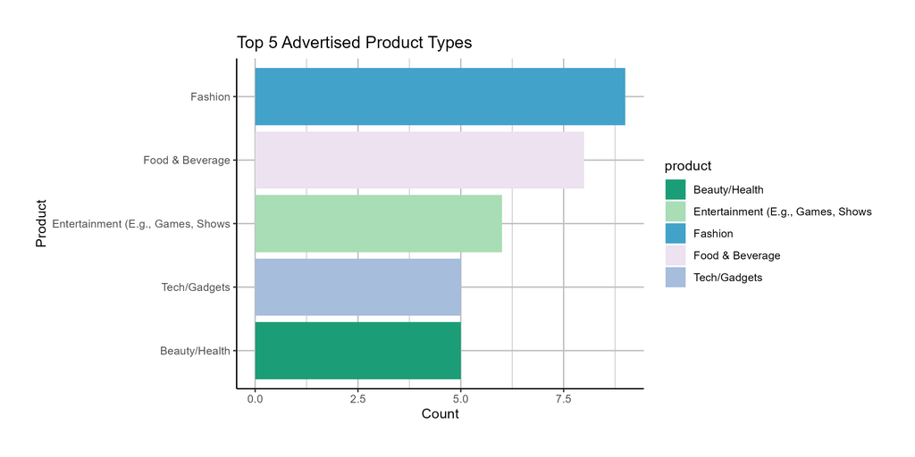

Bar chart showing top 5 product types advertised. Fashion leads, followed by Food & Beverage, Entertainment, Tech/Gadgets, and Beauty/Health.

Fashion dominates my ad feed. That’s not a surprise considering the influencers and clothing brands I follow. Ads for food, entertainment, and gadgets followed — areas that also align with my recent searches and scroll patterns.

These results reflect how Instagram’s algorithms customize content based on users’ digital footprints.

## Do Ad Formats Affect Interaction?

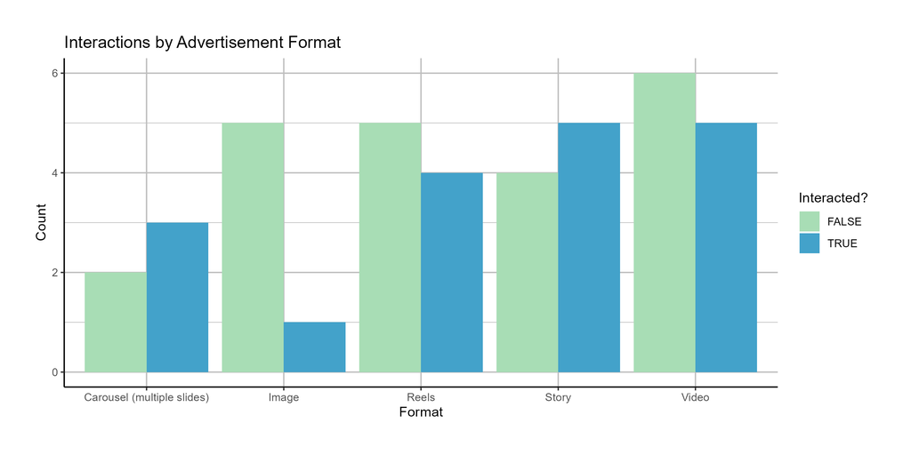

The structure and timing of the ad — not just the product — clearly influence engagement.

## When Do Ads Appear the Most?

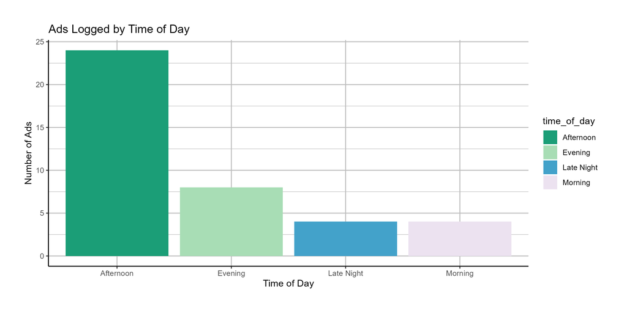

Bar chart showing number of ads seen by time of day, with Afternoon being the highest.

Most ads appeared in the **afternoon**, followed by **evening**. This matches my personal usage — I scroll the most after university lectures and while taking breaks.

This reinforces how platforms strategically deliver ads when users are most active and responsive.

## Summary

Even with a small and personal data set like this, it’s easy to see how Instagram’s advertising system is designed to match not just who I am — but *when* and *how* I interact with content. Once you notice it, it’s kind of hard to ignore.